# CAMBRAY_SERVIN_ERICK_proyecto

## Entrega Final Diplomando Data Science

- Erick Alexei Cambray Servin

```python
import pandas as pd
import numpy as np

import matplotlib.pyplot as plt
import seaborn as sns

from scipy.stats import shapiro, bartlett
import statsmodels.api as sm

import os
sns.set()

pd.options.display.max_columns = None
```

Teniendo esta información vamos a poder hacer una nueva columna la cual vamos a hacer una columna de clasificación sobre la que se hará el análisis de severidad, crearemos una columna que diga 1 si es que la severidad está entre 1 y 2. En 0 si es que está en 3 y 4. Lo que nos dirá que tan grave es un accidente dependiendo de las condiciones en las que sucedió el accidente

```python
dataPath = '/Users/admin/Documents/Personal/data/'
```

```python
data = pd.read_csv(dataPath + '/US_Accidents_Dec21_updated.csv')
data.columns
```

```
Index(['ID', 'Severity', 'Start_Time', 'End_Time', 'Start_Lat', 'Start_Lng',
       'End_Lat', 'End_Lng', 'Distance(mi)', 'Description', 'Number', 'Street',
       'Side', 'City', 'County', 'State', 'Zipcode', 'Country', 'Timezone',
       'Airport_Code', 'Weather_Timestamp', 'Temperature(F)', 'Wind_Chill(F)',
       'Humidity(%)', 'Pressure(in)', 'Visibility(mi)', 'Wind_Direction',
       'Wind_Speed(mph)', 'Precipitation(in)', 'Weather_Condition', 'Amenity',
       'Bump', 'Crossing', 'Give_Way', 'Junction', 'No_Exit', 'Railway',
       'Roundabout', 'Station', 'Stop', 'Traffic_Calming', 'Traffic_Signal',
       'Turning_Loop', 'Sunrise_Sunset', 'Civil_Twilight', 'Nautical_Twilight',
       'Astronomical_Twilight'],
      dtype='object')
```

```python
data.head()
```

|  | ID | Severity | Start_Time | End_Time | Start_Lat | Start_Lng | End_Lat | End_Lng | Distance(mi) | Description | Number | Street | Side | City | County | State | Zipcode | Country | Timezone | Airport_Code | Weather_Timestamp | Temperature(F) | Wind_Chill(F) | Humidity(%) | Pressure(in) | Visibility(mi) | Wind_Direction | Wind_Speed(mph) | Precipitation(in) | … |
| --- | --- | --- | --- | --- | --- | --- | --- | --- | --- | --- | --- | --- | --- | --- | --- | --- | --- | --- | --- | --- | --- | --- | --- | --- | --- | --- | --- | --- | --- | --- |
| 0 | A-1 | 3 | 2016-02-08 00:37:08 | 2016-02-08 06:37:08 | 40.108910 | -83.092860 | 40.112060 | -83.031870 | 3.230 | Between Sawmill Rd/Exit 20 and OH-315/Olentang... | NaN | Outerbelt E | R | Dublin | Franklin | OH | 43017 | US | US/Eastern | KOSU | 2016-02-08 00:53:00 | 42.1 | 36.1 | 58.0 | 29.76 | 10.0 | SW | 10.4 | 0.00 | … |
| 1 | A-2 | 2 | 2016-02-08 05:56:20 | 2016-02-08 11:56:20 | 39.865420 | -84.062800 | 39.865010 | -84.048730 | 0.747 | At OH-4/OH-235/Exit 41 - Accident. | NaN | I-70 E | R | Dayton | Montgomery | OH | 45424 | US | US/Eastern | KFFO | 2016-02-08 05:58:00 | 36.9 | NaN | 91.0 | 29.68 | 10.0 | Calm | NaN | 0.02 | … |
| 2 | A-3 | 2 | 2016-02-08 06:15:39 | 2016-02-08 12:15:39 | 39.102660 | -84.524680 | 39.102090 | -84.523960 | 0.055 | At I-71/US-50/Exit 1 - Accident. | NaN | I-75 S | R | Cincinnati | Hamilton | OH | 45203 | US | US/Eastern | KLUK | 2016-02-08 05:53:00 | 36.0 | NaN | 97.0 | 29.70 | 10.0 | Calm | NaN | 0.02 | … |
| 3 | A-4 | 2 | 2016-02-08 06:51:45 | 2016-02-08 12:51:45 | 41.062130 | -81.537840 | 41.062170 | -81.535470 | 0.123 | At Dart Ave/Exit 21 - Accident. | NaN | I-77 N | R | Akron | Summit | OH | 44311 | US | US/Eastern | KAKR | 2016-02-08 06:54:00 | 39.0 | NaN | 55.0 | 29.65 | 10.0 | Calm | NaN | NaN | … |
| 4 | A-5 | 3 | 2016-02-08 07:53:43 | 2016-02-08 13:53:43 | 39.172393 | -84.492792 | 39.170476 | -84.501798 | 0.500 | At Mitchell Ave/Exit 6 - Accident. | NaN | I-75 S | R | Cincinnati | Hamilton | OH | 45217 | US | US/Eastern | KLUK | 2016-02-08 07:53:00 | 37.0 | 29.8 | 93.0 | 29.69 | 10.0 | WSW | 10.4 | 0.01 | … |

```python
data['Grado_Severidad'] = [1 if (x==1 or x==2) else 0 for x in data['Severity']]
```

```python
data.shape
```

```
(2845342, 48)
```

```python
data.isna().sum()
```

```
ID                             0
Severity                       0
Start_Time                     0
End_Time                       0
Start_Lat                      0
Start_Lng                      0
End_Lat                        0
End_Lng                        0
Distance(mi)                   0
Description                    0
Number                   1743911
Street                         2
Side                           0
City                         137
County                         0
State                          0
Zipcode                     1319
Country                        0
Timezone                    3659
Airport_Code                9549
Weather_Timestamp          50736
Temperature(F)             69274
Wind_Chill(F)             469643
Humidity(%)                73092
Pressure(in)               59200
Visibility(mi)             70546
Wind_Direction             73775
Wind_Speed(mph)           157944
Precipitation(in)         549458
Weather_Condition          70636
Amenity                        0
Bump                           0
Crossing                       0
Give_Way                       0
Junction                       0
No_Exit                        0
Railway                        0
Roundabout                     0
Station                        0
Stop                           0
Traffic_Calming                0
Traffic_Signal                 0
Turning_Loop                   0
Sunrise_Sunset              2867
Civil_Twilight              2867
Nautical_Twilight           2867
Astronomical_Twilight       2867
Grado_Severidad                0
dtype: int64
```

```python
data.drop(['Number', 'Country', 'Amenity'], axis= 1, inplace= True)
data.dropna(subset= ['Zipcode', 'Sunrise_Sunset',
                    'Civil_Twilight', 'Nautical_Twilight', 'Astronomical_Twilight'], axis=0, inplace=True)
```

```python
data.columns
```

```
Index(['ID', 'Severity', 'Start_Time', 'End_Time', 'Start_Lat', 'Start_Lng',
       'End_Lat', 'End_Lng', 'Distance(mi)', 'Description', 'Street', 'Side',
       'City', 'County', 'State', 'Zipcode', 'Timezone', 'Airport_Code',
       'Weather_Timestamp', 'Temperature(F)', 'Wind_Chill(F)', 'Humidity(%)',
       'Pressure(in)', 'Visibility(mi)', 'Wind_Direction', 'Wind_Speed(mph)',
       'Precipitation(in)', 'Weather_Condition', 'Bump', 'Crossing',
       'Give_Way', 'Junction', 'No_Exit', 'Railway', 'Roundabout', 'Station',
       'Stop', 'Traffic_Calming', 'Traffic_Signal', 'Turning_Loop',
       'Sunrise_Sunset', 'Civil_Twilight', 'Nautical_Twilight',
       'Astronomical_Twilight', 'Grado_Severidad'],
      dtype='object')
```

```python
um = ['ID']
trgt = ['Grado_Severidad']

cont_var = ['Distance(mi)', 'Temperature(F)', 'Wind_Chill(F)', 'Humidity(%)',
       'Pressure(in)', 'Visibility(mi)', 'Wind_Speed(mph)', 'Precipitation(in)']

cat_var = ['City','State' ,'Zipcode', 'Timezone', 'Airport_Code',
            'Wind_Direction', 'Weather_Condition','Sunrise_Sunset',
            'Civil_Twilight', 'Nautical_Twilight', 'Astronomical_Twilight']


bin_var = ['Bump', 'Crossing', 'Give_Way', 'Junction',
            'No_Exit', 'Railway', 'Roundabout', 'Station',
            'Stop', 'Traffic_Calming', 'Traffic_Signal', 'Turning_Loop']
```

## Imputaciones

```python
from sklearn.impute import SimpleImputer

for col in cont_var:
    data[col] = SimpleImputer(strategy= 'mean').fit_transform(data[[col]])
```

```python
for col in cat_var:
    print(col)
    data[col] = SimpleImputer(strategy= 'most_frequent').fit_transform(data[[col]])
```

```
City
State
Zipcode
Timezone
Airport_Code
Wind_Direction
Weather_Condition
Sunrise_Sunset
Civil_Twilight
Nautical_Twilight
Astronomical_Twilight
```

```python
data.dropna(subset= bin_var, axis=0, inplace= True)
```

```python
data.sample(frac= 0.5).to_csv(dataPath + 'data_clean_proyecto.csv', index= False)
```

```python
data = pd.read_csv(dataPath + 'data_clean_proyecto.csv')
```

### Normalización discreta

```python
def normalizar(df,v,umbral):
    aux = df[v].value_counts(True).to_frame()
    aux[f'n_{v}'] = np.where( aux[v] < umbral , 'Otro' , aux.index )

    moda = aux.head(1)[f'n_{v}'].values[0]

    if aux.loc[aux[f'n_{v}'] == 'Otro' ][v].sum() < umbral:
        aux[f'n_{v}'].replace( {'Otro':moda} , inplace=True)

    aux.drop(v, axis=1, inplace=True)
    aux.reset_index(inplace=True)

    return df.merge(aux,left_on=[v], right_on='index', how='inner').drop('index',axis=1)
```

```python
for v in cat_var:
    data = normalizar(data,v,0.05)

for v in bin_var:
    data = normalizar(data,v,0.05)
```

```python
varn = [x for x in data.columns if x[0:2] == 'n_']
varn
```

```
['n_City',
 'n_State',
 'n_Zipcode',
 'n_Timezone',
 'n_Airport_Code',
 'n_Wind_Direction',
 'n_Weather_Condition',
 'n_Sunrise_Sunset',
 'n_Civil_Twilight',
 'n_Nautical_Twilight',
 'n_Astronomical_Twilight',
 'n_Bump',
 'n_Crossing',
 'n_Give_Way',
 'n_Junction',
 'n_No_Exit',
 'n_Railway',
 'n_Roundabout',
 'n_Station',
 'n_Stop',
 'n_Traffic_Calming',
 'n_Traffic_Signal',
 'n_Turning_Loop']
```

```python
unarias = [v for v,conteo in zip( varn , [data[v].unique().shape[0] for v in varn] ) if conteo == 1]
varn = [v for v in varn  if v not in unarias]
unarias
```

```
['n_City',
 'n_Zipcode',
 'n_Airport_Code',
 'n_Bump',
 'n_Give_Way',
 'n_No_Exit',
 'n_Railway',
 'n_Roundabout',
 'n_Station',
 'n_Stop',
 'n_Traffic_Calming',
 'n_Turning_Loop']
```

## Normalización Continua

```python
from sklearn.preprocessing import KBinsDiscretizer

def discretizar(df, v, k):

    kb = KBinsDiscretizer( n_bins = k , encode='ordinal', strategy='quantile')
    kb.fit(df[[v]])
    df[f'd_{v}_{k}'] = pd.cut( df[v] , bins=kb.bin_edges_[0] , include_lowest=True ).astype(str)

    return df
```

```python
for v in cont_var:
    for k in range(3,5):
        data = discretizar(data, v, k)
```

[output not shown]

[output cut: 14 more lines]

```python
vari =[x for x in data.columns if x[0:2] == 'd_']
vari
```

```
['d_Distance(mi)_3',
 'd_Distance(mi)_4',
 'd_Temperature(F)_3',
 'd_Temperature(F)_4',
 'd_Wind_Chill(F)_3',
 'd_Wind_Chill(F)_4',
 'd_Humidity(%)_3',
 'd_Humidity(%)_4',
 'd_Pressure(in)_3',
 'd_Pressure(in)_4',
 'd_Visibility(mi)_3',
 'd_Visibility(mi)_4',
 'd_Wind_Speed(mph)_3',
 'd_Wind_Speed(mph)_4',
 'd_Precipitation(in)_3',
 'd_Precipitation(in)_4']
```

## Information Value

```python
def calculo_iv( df, v, tgt ):
    aux = df.pivot_table( index = v,
                         columns= tgt,
                         values = um[0],
                         aggfunc= 'count',
                         fill_value=0 )

    aux[list( range(2) ) ] = aux/aux.apply(np.sum)

    aux['w'] = np.log( aux[0] / aux[1] )
    aux['iv'] = (aux[0] - aux[1]) * aux['w']

    return v, aux['iv'].sum()
```

### Primera partcion IV

```python
from sklearn.model_selection import train_test_split

Xt, Xv, yt, yv = train_test_split(data[vari + um], data[trgt + um])
Xt = Xt.merge( yt , on=um, how='inner').reset_index(drop=True)
```

```python
# iv de discretizadas -> vari
iv = pd.DataFrame( map( lambda v: calculo_iv( data, v, trgt  ) , vari ) ,
                  columns=['variable','iv'] )

iv['raiz'] = iv['variable'].map( lambda x: '_'.join(x.split('_')[1:2] ) )
iv = iv.sort_values(by=['raiz','iv'],ascending=[1,0]).reset_index(drop=True)

# Eliminación de ivs infs
iv = iv.loc[iv['iv'] != np.inf].reset_index(drop=True)
iv['id'] = iv.groupby('raiz').cumcount()+1
iv = iv.loc[iv.id == 1]

iv.drop(columns=['raiz','id'],inplace=True)
```

```python
besti = iv['variable'].tolist()

len(besti) , besti
```

```
(7,
 ['d_Distance(mi)_4',
  'd_Humidity(%)_4',
  'd_Precipitation(in)_4',
  'd_Pressure(in)_4',
  'd_Temperature(F)_4',
  'd_Visibility(mi)_3',
  'd_Wind_Chill(F)_4'])
```

## Segunda partición

```python
Xt, Xv, yt, yv = train_test_split(data[besti+ varn + um], data[trgt + um])
Xt = Xt.merge( yt , on=um, how='inner').reset_index(drop=True)
```

```python
ivd = pd.DataFrame( map( lambda v: calculo_iv(data, v, trgt) , varn ) ,
                   columns=['variable','iv'] )

iv = pd.concat([ iv, ivd ], ignore_index=True)
iv.sort_values(by='iv',ascending=False)
```

|  | variable | iv |
| --- | --- | --- |
| 10 | n_Weather_Condition | 0.462614 |
| 7 | n_State | 0.375293 |
| 6 | d_Wind_Chill(F)_4 | 0.309744 |
| 8 | n_Timezone | 0.249392 |
| 9 | n_Wind_Direction | 0.142280 |
| 3 | d_Pressure(in)_4 | 0.086304 |
| 0 | d_Distance(mi)_4 | 0.083205 |
| 16 | n_Junction | 0.039375 |
| 5 | d_Visibility(mi)_3 | 0.011345 |
| 4 | d_Temperature(F)_4 | 0.010201 |
| 15 | n_Crossing | 0.004887 |
| 1 | d_Humidity(%)_4 | 0.003699 |
| 17 | n_Traffic_Signal | 0.001776 |
| 2 | d_Precipitation(in)_4 | 0.000975 |
| 11 | n_Sunrise_Sunset | 0.000141 |
| 12 | n_Civil_Twilight | 0.000138 |
| 14 | n_Astronomical_Twilight | 0.000055 |
| 13 | n_Nautical_Twilight | 0.000023 |

```python
best = iv['variable'].tolist()
best
```

```
['d_Distance(mi)_4',
 'd_Humidity(%)_4',
 'd_Precipitation(in)_4',
 'd_Pressure(in)_4',
 'd_Temperature(F)_4',
 'd_Visibility(mi)_3',
 'd_Wind_Chill(F)_4',
 'n_State',
 'n_Timezone',
 'n_Wind_Direction',
 'n_Weather_Condition',
 'n_Sunrise_Sunset',
 'n_Civil_Twilight',
 'n_Nautical_Twilight',
 'n_Astronomical_Twilight',
 'n_Crossing',
 'n_Junction',
 'n_Traffic_Signal']
```

## WOE

```python
Xt, Xv, yt, yv = train_test_split(data[best + um], data[trgt + um])

print(Xt.shape, Xv.shape, yt.shape[0], yv.shape[0])

Xt = Xt.merge( yt , on=um, how='inner').reset_index(drop=True)
Xv = Xv.merge( yv , on=um, how='inner').reset_index(drop=True)
```

```
(1065444, 19) (355148, 19) 1065444 355148
```

```python
def codificacion_woe(df, v, tgt):
    aux = df.pivot_table( index=v,
                          columns=tgt,
                          values=um[0],
                          aggfunc='count',
                          fill_value=0)

    aux[list( range(2) )] = aux / aux.apply(np.sum)

    aux['w'] = np.log( aux[0] / aux[1] )

    aux.drop(range(2) , axis=1 , inplace=True )

    aux = aux.to_dict()['w']

    return v, aux
```

```python
mapa_woe = list( map(  lambda v: codificacion_woe( Xt , v , trgt  ) , best  ) )
```

```python
for v, mapa in mapa_woe:
    Xt[f'w_{v}'] = Xt[v].replace(mapa)
    Xv[f'w_{v}'] = Xv[v].replace(mapa)
```

## TAD

```python
X_y = pd.concat([Xt, Xv], axis=0)
woe_var = [x for x in X_y.columns if x[0:2]== 'w_']
woe_var
```

```
['w_d_Distance(mi)_4',
 'w_d_Humidity(%)_4',
 'w_d_Precipitation(in)_4',
 'w_d_Pressure(in)_4',
 'w_d_Temperature(F)_4',
 'w_d_Visibility(mi)_3',
 'w_d_Wind_Chill(F)_4',
 'w_n_State',
 'w_n_Timezone',
 'w_n_Wind_Direction',
 'w_n_Weather_Condition',
 'w_n_Sunrise_Sunset',
 'w_n_Civil_Twilight',
 'w_n_Nautical_Twilight',
 'w_n_Astronomical_Twilight',
 'w_n_Crossing',
 'w_n_Junction',
 'w_n_Traffic_Signal']
```

```python
tad = X_y[um + woe_var + trgt]
tad.iloc[0:3,:].head().to_clipboard()
```

## Modelado de datos y preparación para modelado

Justificación:

Una vez que tenemos los datos ya limpios y las variables seleccionadas con el uso de la prepación WoE podemos entoces tener modelos que puedan medir dentro de las condiciones climáticas junto con los datos de la zona poder decir si es que los accidentes de alta severidad son probables y con la nueva tecnología en autos tener alertas especiales de conducción si es que las probabilidades aumentaran.

Para poder ver seleccionar las variables del modelo aparte de usar el IV vamos a probar los supuestos que nos permitirían modelar con el algoritmo de regresión logística.

```python
X = tad[woe_var].copy()
y = tad['Grado_Severidad']
y.value_counts(normalize = True)
```

```
1    0.899312
0    0.100688
Name: Grado_Severidad, dtype: float64
```

Tenemos una clase desbalanceada pero para eso se pueden aplicar técnias de muestreo y en dimensiones

```python
Xt, Xv, yt, yv = train_test_split(X, y, train_size= 0.7, random_state= 0)
```

Ahora hacemos el submuestreo

```python
from imblearn.under_sampling import TomekLinks

tomlinks = TomekLinks(sampling_strategy='auto', n_jobs= -1)

Xt, yt = tomlinks.fit_resample(Xt, yt)
```

```python
from sklearn.linear_model import LogisticRegression

logreg = LogisticRegression(max_iter= 10_000)
```

```python
logreg.fit(Xt,yt)
predicted = logreg.predict(Xv)
```

```python
from sklearn.metrics import classification_report, f1_score, recall_score, precision_recall_curve, accuracy_score
```

```python
print(classification_report(yv, predicted))
```

```
              precision    recall  f1-score   support

           0       0.43      0.04      0.07     42916
           1       0.90      0.99      0.95    383262

    accuracy                           0.90    426178
   macro avg       0.67      0.52      0.51    426178
weighted avg       0.85      0.90      0.86    426178
```

```python
print(f'Accuracy: {accuracy_score(y_true= yv, y_pred= predicted)}')
print(f'Recall: {recall_score(y_true= yv, y_pred= predicted)}')
print(f'F1_score: {f1_score(y_true= yv, y_pred= predicted)}')
```

```
Accuracy: 0.8980637198541455
Recall: 0.9944607083405086
F1_score: 0.9460818322967877
```

Verificamos la normalidad de los residuos

```python
shapiro_test = shapiro(residuals)
print("Shapiro-Wilk test: W = %f, p-value = %f" % shapiro_test)
```

[output not shown]

Con esto vemos que realmente no hay una buena distribución de los errores. Por lo que se tendría que hacer una predicción con un cambio de modelo

```python
from xgboost import XGBClassifier
xgbC = XGBClassifier()
```

```python
xgbC.fit(Xt, yt)
y_predicted = xgbC.predict(Xv)

print(classification_report(yv, y_predicted))
```

```
              precision    recall  f1-score   support

           0       0.60      0.15      0.24     42916
           1       0.91      0.99      0.95    383262

    accuracy                           0.90    426178
   macro avg       0.76      0.57      0.59    426178
weighted avg       0.88      0.90      0.88    426178
```

```python
print(f'Accuracy: {accuracy_score(y_true= yv, y_pred= y_predicted)}')
print(f'Recall: {recall_score(y_true= yv, y_pred= y_predicted)}')
print(f'F1_score: {f1_score(y_true= yv, y_pred= y_predicted)}')
```

```
Accuracy: 0.9044929583413504
Recall: 0.9891092777264638
F1_score: 0.9490498561108754
```

Podemos ver que aunque no se cumplían algunos supuestos para poder hacer el uso de la regresión logística aún así los valores que tenemos son relativamente similares con un modelo más potente lo que nos dice que es correcto usar la transformación para el uso de ambos modelos

## Formación de solución de negocio

El principal uso que se le puede dar a la información obtenida se puede hacer en carros con conexión a internet una alterta de manejo para poder tener más cuidado en las partes donde se tenga probabilidades de tener un choque Grave entonces tener medidas adicionales.

```python
xgbC.predict_proba(tad[woe_var])
```

```
array([[0.03021413, 0.96978587],
       [0.02873623, 0.97126377],
       [0.0239591 , 0.9760409 ],
       ...,
       [0.43533665, 0.56466335],
       [0.6321455 , 0.36785445],
       [0.05296403, 0.94703597]], dtype=float32)
```

```python
tad.loc[:,'proba'] = xgbC.predict_proba(tad[woe_var])[:,1]
```

Primero hay que regresar los valores de WoE a sus originales para ser más entendible

```python
reverse_woe = []
for key, dic in mapa_woe:
    reversed_dic = {v: k for k, v in dic.items()}
    reverse_woe.append((key, reversed_dic))
```

```python
final = pd.DataFrame()
for v, mapa in reverse_woe:
    final[v] = tad[f'w_{v}'].replace(mapa)
final['target'] = tad['Grado_Severidad']
final['proba'] = tad['proba']

final.head()
```

|  | d_Distance(mi)_4 | d_Humidity(%)_4 | d_Precipitation(in)_4 | d_Pressure(in)_4 | d_Temperature(F)_4 | d_Visibility(mi)_3 | d_Wind_Chill(F)_4 | n_State | n_Timezone | n_Wind_Direction | n_Weather_Condition | n_Sunrise_Sunset | n_Civil_Twilight | n_Nautical_Twilight | n_Astronomical_Twilight | n_Crossing | n_Junction | n_Traffic_Signal | target | proba |
| --- | --- | --- | --- | --- | --- | --- | --- | --- | --- | --- | --- | --- | --- | --- | --- | --- | --- | --- | --- | --- |
| 0 | (0.052, 0.243] | (0.999, 49.0] | (-0.001, 0.00702] | (0.299, 29.33] | (75.9, 196.0] | (-0.001, 10.0] | (73.0, 196.0] | Otro | US/Mountain | W | Fair | Day | Day | Day | Day | True | False | True | 1 | 0.969786 |
| 1 | (0.243, 0.763] | (49.0, 66.0] | (-0.001, 0.00702] | (30.01, 58.16] | (75.9, 196.0] | (-0.001, 10.0] | (73.0, 196.0] | FL | US/Eastern | Otro | Mostly Cloudy | Day | Day | Day | Day | False | False | False | 1 | 0.971264 |
| 2 | (0.243, 0.763] | (66.0, 83.0] | (-0.001, 0.00702] | (29.33, 29.81] | (63.0, 75.9] | (-0.001, 10.0] | (59.665, 73.0] | CA | US/Pacific | CALM | Otro | Day | Day | Day | Day | False | False | False | 1 | 0.976041 |
| 3 | (0.763, 152.543] | (83.0, 100.0] | (-0.001, 0.00702] | (0.299, 29.33] | (-50.001, 50.0] | (-0.001, 10.0] | (-80.001, 51.0] | Otro | US/Central | CALM | Otro | Day | Day | Day | Day | False | False | False | 1 | 0.975072 |
| 4 | (0.052, 0.243] | (66.0, 83.0] | (-0.001, 0.00702] | (29.81, 30.01] | (-50.001, 50.0] | (-0.001, 10.0] | (-80.001, 51.0] | CA | US/Pacific | Otro | Partly Cloudy | Night | Day | Day | Day | True | False | False | 1 | 0.986158 |

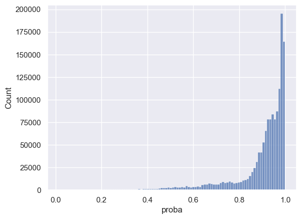

```python
sns.histplot(final['proba'], bins= 100)
```

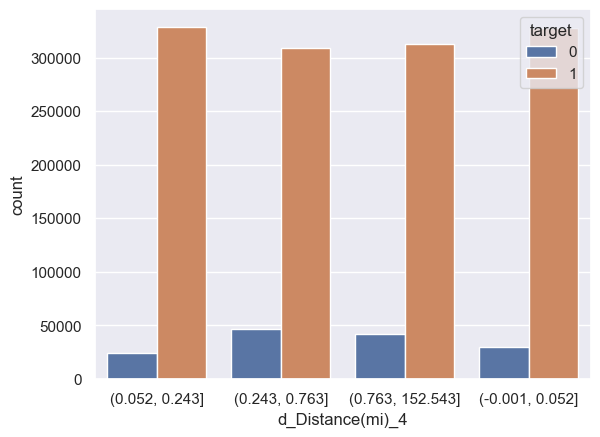

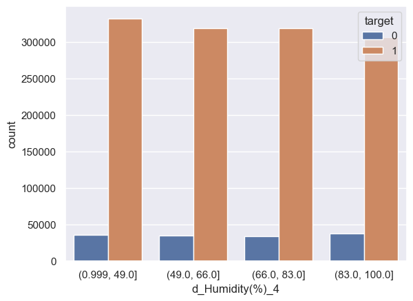

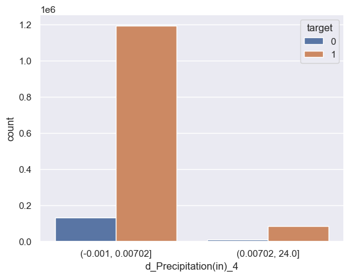

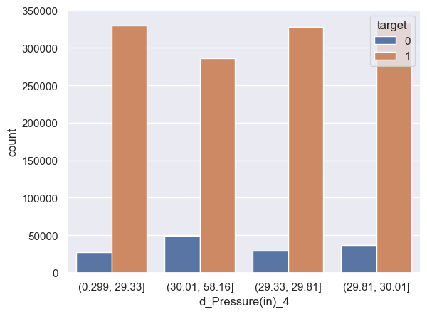

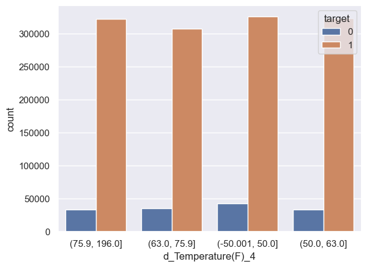

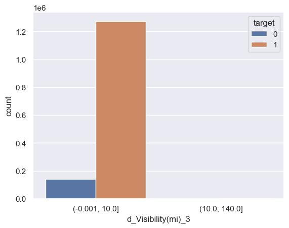

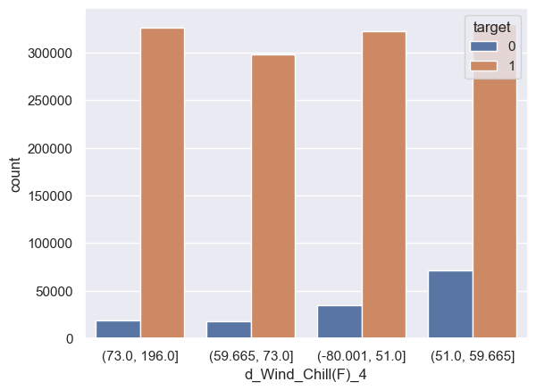

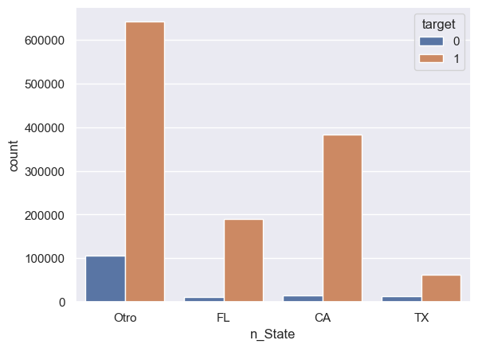

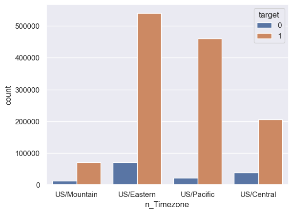

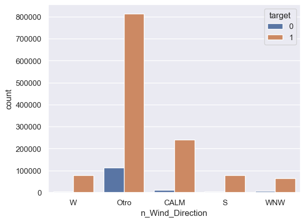

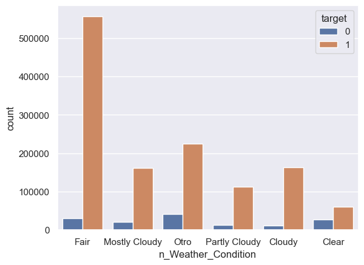

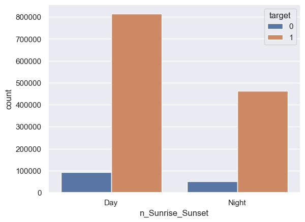

[6 more figures not shown]

```python
for col in final.columns[0:-1]:
    sns.countplot(data=final, x= col, hue= 'target')
    plt.show()
```